# UMCCR Patient Summary

Oliver Hofmann

2018-02-16

## Allelic frequencies

Comparing the allelic frequencies of all somatic mutations vs those present in a subset of ~300 known cancer genes. Frequencies are currently based on Mutect2 calls only and limited to ‘high confidence’ regions as determined by the [Genome in a Botte consortium].

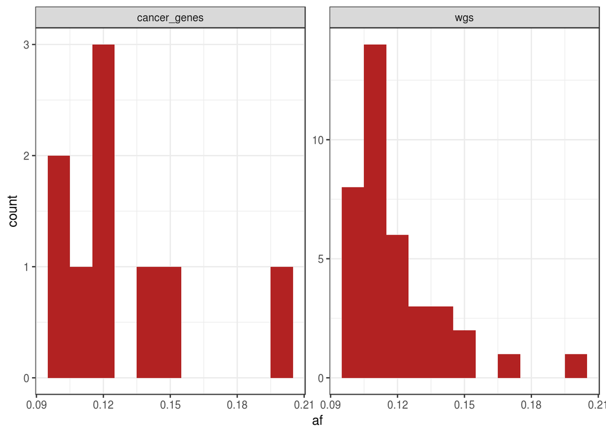

```r
# Global AF
af <- readr::read_tsv(params$af_freqs, col_names = "af", col_types = "d") %>%
  dplyr::mutate(set = "wgs")

# AF for AstraZeneca's AZ300 gene set
af_az300 <- readr::read_tsv(params$af_freqs_az300, col_names = "af", col_types = "-----d-") %>%
  dplyr::mutate(set = 'cancer_genes')

dplyr::bind_rows(af, af_az300) %>%
  ggplot(aes(af)) +
  geom_histogram(stat = 'bin', binwidth = 0.01, fill = "firebrick") +
  facet_wrap(~set, scales = 'free_y') +
  theme_bw()
```

```r
mode <- function(x) {
  ux <- unique(x)
  ux[which.max(tabulate(match(x, ux)))]
}
```

Based on all variants we are seeing a mean allelic frequency of 0.12 (median 0.1143, mode 0.102). Looking at just SNVs in known cancer genes this changes to mean 0.13 (median 0.119, mode 0.1483).

## Mutational signature

[PCGR](https://github.com/sigven/pcgr) uses [deconstructSigs](https://cran.r-project.org/web/packages/deconstructSigs/index.html) to generate somatic signatures. From our experience it can miss signatures quite frequently; using [MutationalPatterns](http://bioconductor.org/packages/release/bioc/html/MutationalPatterns.html) to doublecheck.

```r
# Grab ensemble calls from the post-processing stage. These were converted
# by adding "chr" prefixes and remiving G* chromosomes.
#

vcf <- read_vcfs_as_granges(
  params$vcf_fname,
  sample_names = params$tumor_name,
  genome = ref_genome,
  group = "auto+sex")
```

### Look at somatic change distribution:

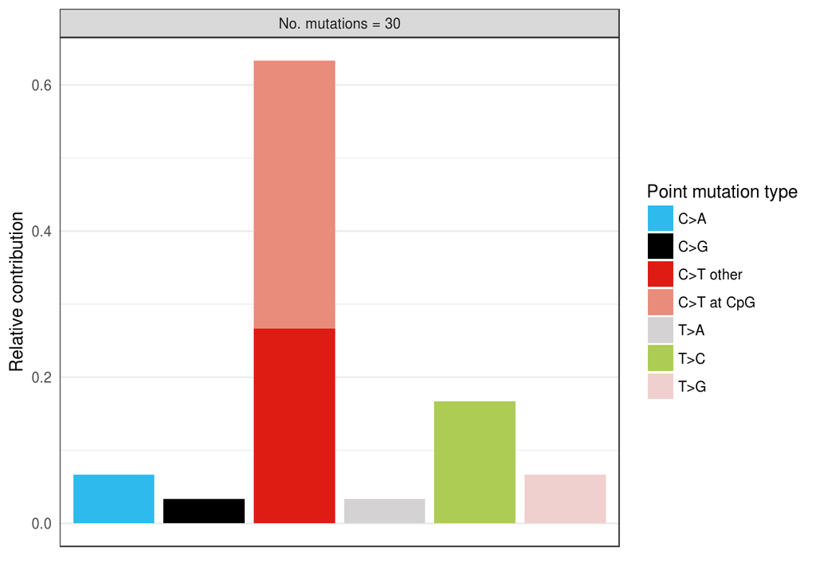

```r
type_occurrences <- mut_type_occurrences(vcf, ref_genome = ref_genome)
plot_spectrum(type_occurrences, CT = TRUE)
```

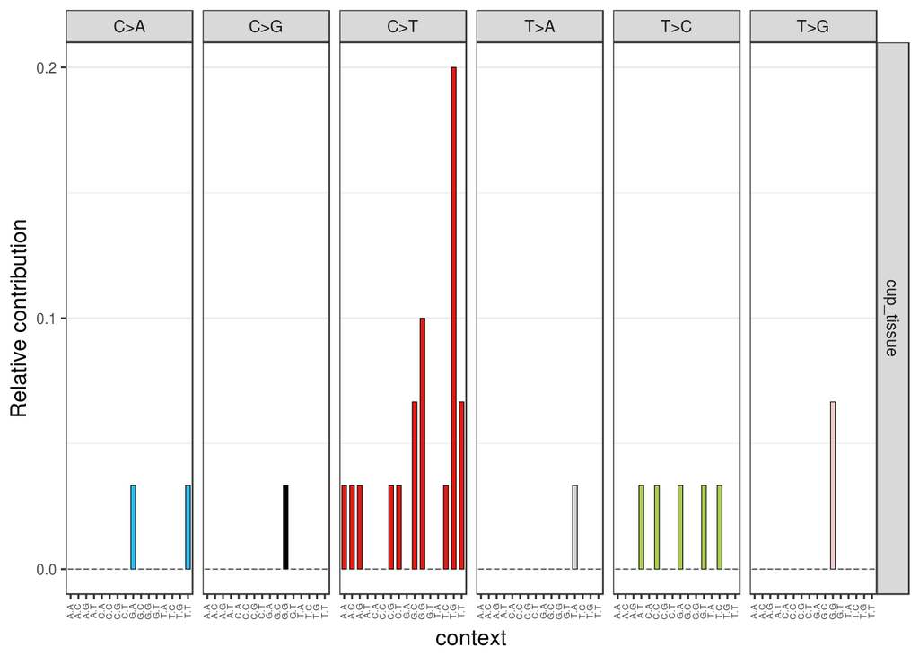

```r
# Could do this relative to a few reference samples
mut_mat <- mut_matrix(vcf_list = vcf, ref_genome = ref_genome)
plot_96_profile(mut_mat)
```

### Extract somatic signatures and compare to the reference set:

```r
# Get Sanger sigs
# sp_url <- paste("http://cancer.sanger.ac.uk/cancergenome/assets/", "signatures_probabilities.txt", sep = "")
sp_url <- params$sig_probs
# better be explicit - the sig_probs file has 7 extra empty columns
col_types <- paste0(c("ccc", paste0(rep("d", 30), collapse = ""), "ccccccc"), collapse = "")
col_names <- c("SubstType", "Trinucleotide", "SomMutType", paste0("Sig", 1:30), paste0("foo", 1:7))
cancer_signatures <- readr::read_tsv(sp_url, col_names = col_names, col_types = col_types, skip = 1) %>%
  dplyr::arrange(SubstType) %>%
  dplyr::select(4:33) %>%
  as.matrix()

# Fit mutation matrix to cancer signatures. This function finds the optimal linear
# combination of mutation signatures that most closely reconstructs the
# mutation matrix by solving a non-negative least-squares constraints problem.
fit_res <- fit_to_signatures(mut_mat, cancer_signatures)
# Select signatures with some contribution
fit_res_contr <- fit_res$contribution[fit_res$contribution[, 1] > 0, ]
result <- data.frame(Signature = names(fit_res_contr), Contribution = fit_res_contr)

# Quick summary of the results; no plotting yet
result %>%
  dplyr::select(Signature, Contribution) %>%
  dplyr::arrange(-Contribution) %>%
  DT::datatable(rownames = FALSE) %>%
  DT::formatRound('Contribution', 1)
```

| Signature | Contribution |
| --- | --- |
| Sig1 | 10.28963248824 |
| Sig10 | 8.38766826811671 |
| Sig15 | 6.05307246035405 |
| Sig7 | 4.26797608221203 |
| Sig21 | 2.23941331129693 |
| Sig26 | 0.194296103444222 |
| Sig27 | 0.102367396165046 |

### Check for positional enrichment of somatic signatures (limited to autosomes):

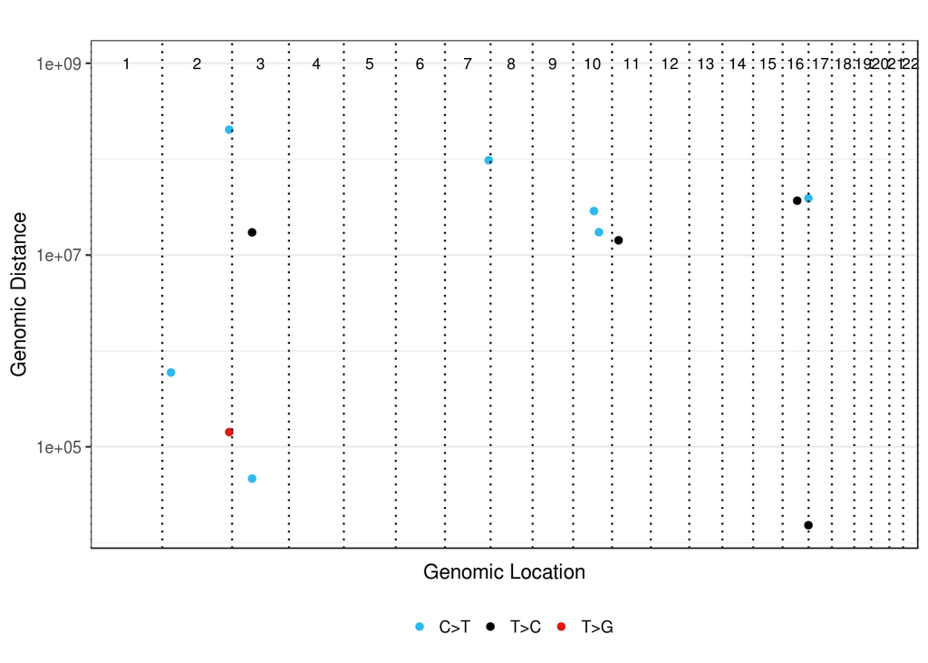

```r
chromosomes <- seqnames(get(ref_genome))[1:22]
plot_rainfall(vcf[[1]], chromosomes = chromosomes, cex = 1.5, ylim = 1e+09 )
```

## Prioritised structural variants

```r
col_types <- "ccciicccccc"
cnv_all <- readr::read_tsv(params$sv_fname, col_names = TRUE, col_types = col_types) %>%
  tidyr::unnest(annotation = strsplit(annotation, ',')) %>% # Unpack multiple annotations per region
  tidyr::separate(annotation,
                  c('type', 'annotation', 'gene', 'transcript', 'priority', 'score'),
                  sep = '\\|') %>% # Unpack annotation columns %>%
  dplyr::select(chrom, start, end, gene, priority, score, annotation, type, lof,
                split_read_support, paired_support_PR) %>%
  dplyr::distinct()

DT::datatable(cnv_all, rownames = FALSE)
```

| chrom | start | end | gene | priority | score | annotation | type | lof | split_read_support | paired_support_PR |
| --- | --- | --- | --- | --- | --- | --- | --- | --- | --- | --- |
| 3 | 60375800 | 60529132 | FHIT | NOT_PRIORITISED | 3 | UPSTREAM_GENE_VARIANT | DEL | (FHIT\|ENSG00000189283\|8\|0.63) | 319,47 | 415,78 |
| 3 | 60375800 | 60529132 | FHIT | NOT_PRIORITISED | 3 | DOWNSTREAM_GENE_VARIANT | DEL | (FHIT\|ENSG00000189283\|8\|0.63) | 319,47 | 415,78 |
| 3 | 60375800 | 60529132 | FHIT | Exon5del | 3 | EXON_DEL | DEL | (FHIT\|ENSG00000189283\|8\|0.63) | 319,47 | 415,78 |
| 3 | 60375800 | 60529132 | FHIT | Exon6del | 3 | EXON_DEL | DEL | (FHIT\|ENSG00000189283\|8\|0.63) | 319,47 | 415,78 |
| 3 | 60375800 | 60529132 | FHIT | Exon1del | 3 | EXON_DEL | DEL | (FHIT\|ENSG00000189283\|8\|0.63) | 319,47 | 415,78 |
| 3 | 60994227 | 62155275 | FHIT&amp;PTPRG | NOT_PRIORITISED | 3 | BIDIRECTIONAL_GENE_FUSION | DUP | (PTPRG\|ENSG00000144724\|7\|0.29) | 356,14 | 540,40 |
| 3 | 137753286 |  | ARHGAP26 | NOT_PRIORITISED | 3 | GENE_FUSION | BND |  | 388,11 | 506,27 |
| 4 | 91724483 | 91847830 | TMSB4XP8 | NOT_PRIORITISED | 3 | UPSTREAM_GENE_VARIANT | DEL | (CCSER1\|ENSG00000184305\|14\|0.14) | 252,6 | 473,10 |
| 4 | 91724483 | 91847830 | CCSER1 | NOT_PRIORITISED | 3 | UPSTREAM_GENE_VARIANT | DEL | (CCSER1\|ENSG00000184305\|14\|0.14) | 252,6 | 473,10 |
| 4 | 91724483 | 91847830 | TMSB4XP8 | NOT_PRIORITISED | 3 | DOWNSTREAM_GENE_VARIANT | DEL | (CCSER1\|ENSG00000184305\|14\|0.14) | 252,6 | 473,10 |

[output cut: 20 more lines]

## Loss of function in tumor suppressors

```r
suppressors <- readr::read_tsv(params$suppressors, col_names = "gene", col_types = "c") %>%
  dplyr::pull(gene)

lof <- cnv_all %>%
  dplyr::mutate(lof = stringr::str_replace_all(lof, '\\(|\\)', '')) %>%
  tidyr::unnest(lof = strsplit(lof, ',')) %>%
  tidyr::separate(lof,
           c('lof_gene', 'geneid', 'transcript_count', 'percent_affected'),
           sep = '\\|') %>%
  dplyr::select(chrom, start, end, lof_gene, transcript_count, percent_affected,
         split_read_support, paired_support_PR) %>%
  dplyr::filter(lof_gene %in% suppressors) %>%
  dplyr::distinct()
DT::datatable(lof, rownames = FALSE)
```

| chrom | start | end | lof_gene | transcript_count | percent_affected | split_read_support | paired_support_PR |
| --- | --- | --- | --- | --- | --- | --- | --- |
| 3 | 60375800 | 60529132 | FHIT | 8 | 0.63 | 319,47 | 415,78 |

## Transcriptional strand bias analysis

We can determine if a gene mutation is on the transcribed or non-transcribed strand, which can be used to evaluate the involvement of transcription-coupled repair. By convention base substitutions are regarded as C>X or T>X, so we try to determine whether the C or T base is on the same strand as the gene definition. Base substitutions on the same strand as the gene definition are considered ‘untranscribed’, and on the opposite strand ‘transcribed’, since the gene definitions report the coding or sense strand, which is untranscribed. No strand information is reported for base substitutions that overlap with more than one gene on different strands.

```r
# Get known genes table from UCSC hg19
genes_hg19 <- genes(TxDb.Hsapiens.UCSC.hg19.knownGene)

# Mutation count matrix with strand info (4*6*4=96 -> 96*2=192)
mut_mat_s <- mut_matrix_stranded(vcf,
                                 ref_genome = ref_genome,
                                 ranges = genes_hg19,
                                 mode = "transcription")

# Mutation count per type and strand
strand_counts <- strand_occurrences(mut_mat_s, by = "all")
# Poisson test for strand asymmetry significance testing
strand_bias <- strand_bias_test(strand_counts)
```

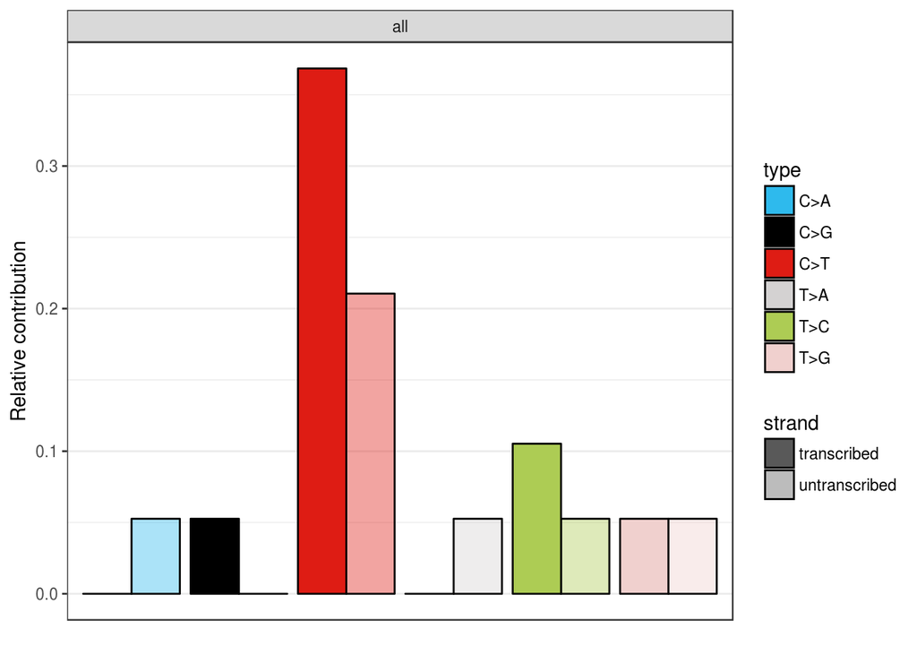

```r
# mutation spectrum with strand distinction
plot_strand(strand_counts, mode = "relative")
```

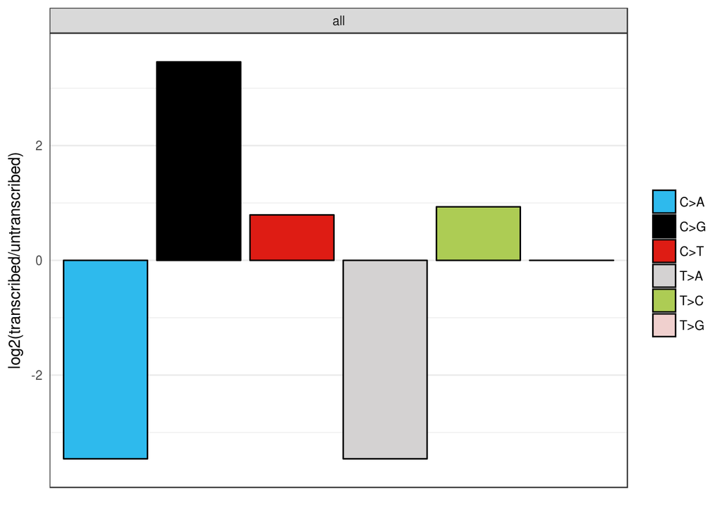

```r
# effect size of strand bias
plot_strand_bias(strand_bias)
```

## Replicative strand bias analysis

The involvement of replication-associated mechanisms can be evaluated by testing for a mutational bias between the leading and lagging strand. The replication strand is dependent on the locations of replication origins from which DNA replication is fired. However, replication timing is dynamic and cell-type specific, which makes replication strand determination less straightforward than transcriptional strand bias analysis. Replication timing profiles can be generated with Repli-Seq experiments. Once the replication direction is defined, a strand asymmetry analysis can be performed similarly as the transcription strand bias analysis.

```r
repli_file <- system.file("extdata/ReplicationDirectionRegions.bed",
                          package = "MutationalPatterns")
# start/stop contain scientific notation, so need to be doubles
repli_strand <- read_tsv(repli_file, col_names = TRUE, col_types = "cddcc") %>%
  mutate_if(is.character, as.factor)
repli_strand_granges <- GRanges(
  seqnames = repli_strand$Chr,
  ranges = IRanges(start = repli_strand$Start + 1,
                   end = repli_strand$Stop),
  strand_info = repli_strand$Class)

seqlevelsStyle(repli_strand_granges) <- seqlevelsStyle(base::get(ref_genome))

mut_mat_s_rep <- mut_matrix_stranded(vcf, ref_genome = ref_genome,
                                     ranges = repli_strand_granges,
                                     mode = "replication")
# Mutation count per type and strand
strand_counts_rep <- strand_occurrences(mut_mat_s_rep, by = "all")
# Poisson test for strand asymmetry significance testing
strand_bias_rep <- strand_bias_test(strand_counts_rep)
```

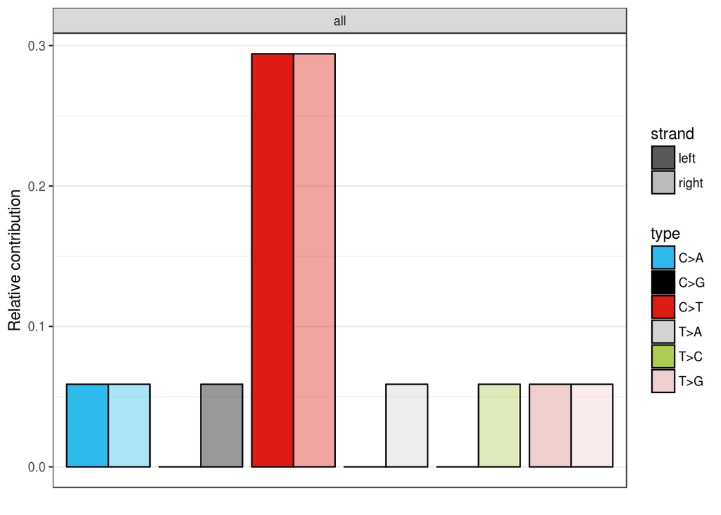

```r
plot_strand(strand_counts_rep, mode = "relative")
```

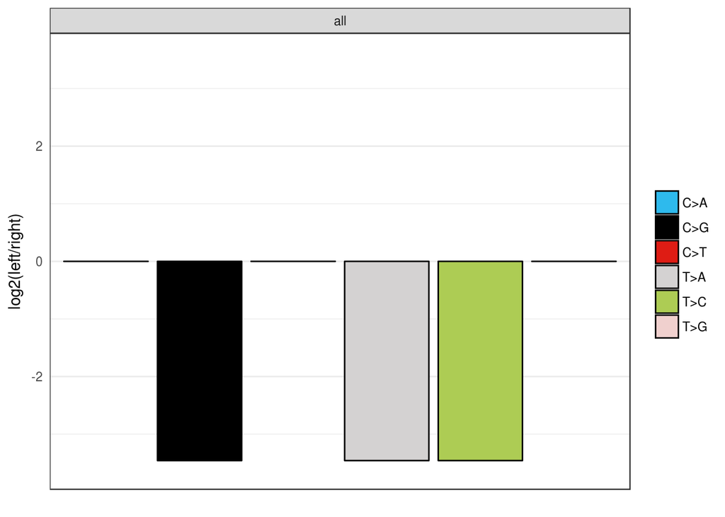

```r
plot_strand_bias(strand_bias_rep)
```

## Addendum

```
##  setting  value
##  version  R version 3.4.1 (2017-06-30)
##  system   x86_64, linux-gnu
##  ui       X11
##  language (EN)
##  collate  en_AU.UTF-8
##  tz       Australia/Melbourne
##  date     2018-02-16
```

```
## Packages ----------------------------------------------------------------------------------------------------------------------------------
```

```
##  package                           * version  date       source
##  AnnotationDbi                     * 1.40.0   2017-11-08 Bioconductor
##  assertthat                          0.1      2013-12-06 CRAN (R 3.4.1)
##  backports                           1.0.5    2017-01-18 CRAN (R 3.4.1)
##  base                              * 3.4.1    2017-08-13 local
##  bindr                               0.1      2016-11-13 CRAN (R 3.4.1)
##  bindrcpp                          * 0.2      2017-06-17 CRAN (R 3.4.1)
##  Biobase                           * 2.38.0   2017-11-07 Bioconductor
##  BiocGenerics                      * 0.24.0   2017-11-06 Bioconductor
##  BiocParallel                        1.12.0   2017-11-06 Bioconductor
##  biomaRt                             2.34.0   2017-11-10 Bioconductor
##  Biostrings                        * 2.46.0   2017-11-06 Bioconductor
##  bit                                 1.1-12   2014-04-09 CRAN (R 3.4.1)
##  bit64                               0.9-5    2015-07-05 CRAN (R 3.4.1)
##  bitops                              1.0-6    2013-08-17 CRAN (R 3.4.1)
##  blob                                1.1.0    2017-06-17 CRAN (R 3.4.1)
##  BSgenome                          * 1.46.0   2017-11-09 Bioconductor
##  BSgenome.Hsapiens.UCSC.hg19       * 1.4.0    2018-02-07 Bioconductor
##  cluster                           * 2.0.6    2017-03-16 CRAN (R 3.4.1)
##  codetools                           0.2-15   2016-10-05 CRAN (R 3.4.1)
##  colorspace                          1.3-2    2016-12-14 CRAN (R 3.4.1)
##  compiler                            3.4.1    2017-08-13 local
##  cowplot                             0.9.1    2017-11-16 CRAN (R 3.4.1)
##  datasets                          * 3.4.1    2017-08-13 local
##  DBI                                 0.6-1    2017-04-01 CRAN (R 3.4.1)
##  DelayedArray                        0.4.1    2017-11-06 Bioconductor
##  devtools                          * 1.13.2   2017-06-02 CRAN (R 3.4.1)
##  digest                              0.6.12   2017-01-27 CRAN (R 3.4.1)
##  doParallel                          1.0.10   2015-10-14 CRAN (R 3.4.1)
##  dplyr                             * 0.7.4    2017-09-28 CRAN (R 3.4.1)
##  DT                                * 0.2      2016-08-09 CRAN (R 3.4.1)
##  evaluate                            0.10.1   2017-06-24 CRAN (R 3.4.1)
##  foreach                             1.4.3    2015-10-13 CRAN (R 3.4.1)
##  GenomeInfoDb                      * 1.14.0   2017-11-07 Bioconductor
##  GenomeInfoDbData                    1.0.0    2018-02-07 Bioconductor
##  GenomicAlignments                   1.14.0   2017-11-08 Bioconductor
##  GenomicFeatures                   * 1.30.0   2017-11-10 Bioconductor
##  GenomicRanges                     * 1.30.0   2017-11-07 Bioconductor
##  ggdendro                            0.1-20   2016-04-27 CRAN (R 3.4.1)
##  ggplot2                           * 2.2.1    2016-12-30 CRAN (R 3.4.1)
```

[output cut: 56 more lines]

```
##  stringr                           * 1.2.0    2017-02-18 CRAN (R 3.4.1)
##  SummarizedExperiment                1.8.0    2017-11-08 Bioconductor
##  tibble                              1.4.2    2018-01-22 CRAN (R 3.4.1)
##  tidyr                             * 0.7.1    2017-09-01 CRAN (R 3.4.1)
##  tidyselect                          0.2.3    2017-11-06 CRAN (R 3.4.1)
##  tools                               3.4.1    2017-08-13 local
##  TxDb.Hsapiens.UCSC.hg19.knownGene * 3.2.2    2018-02-07 Bioconductor
##  utils                             * 3.4.1    2017-08-13 local
##  VariantAnnotation                   1.24.1   2017-11-12 Bioconductor
##  withr                               1.0.2    2016-06-20 CRAN (R 3.4.1)
##  XML                                 3.98-1.6 2017-03-30 CRAN (R 3.4.1)
##  xtable                              1.8-2    2016-02-05 CRAN (R 3.4.1)
##  XVector                           * 0.18.0   2017-11-06 Bioconductor
##  yaml                                2.1.14   2016-11-12 CRAN (R 3.4.1)
##  zlibbioc                            1.24.0   2017-11-05 Bioconductor
```